# Homework06

Alyssa Neuhaus

2/19/2020

This chunk is locating MyDataFile, where my vector data is located. Each object in the vector is separated by a single comma and stringsAsFactors is False so that the characters are not converted into factors.

```r
z <- read.table("MyDataFile.csv",header=TRUE,sep=",", stringsAsFactors=FALSE)
```

This chunk gives the structure of MyDataFile. It contains 2 columns (or variables), and 100 rows (or observations). It then presents each column as a list.

```r
str(z)
```

```
## 'data.frame':    100 obs. of  2 variables:
##  $ Blood_Hg : num  0.18 0.183 0.198 0.2 0.216 0.234 0.279 0.287 0.291 0.291 ...
##  $ sample_id: int  1 2 3 4 5 6 7 8 9 10 ...
```

This chunk is summarizing the data and giving the basic statsitical analyses of each variable. It gives the mean, meadian, min, max, and quartiles for the sample id (which is irrelevant) and the blood hg.

```r
summary(z)
```

```
##     Blood_Hg        sample_id
##  Min.   :0.1800   Min.   :  1.00
##  1st Qu.:0.4753   1st Qu.: 25.75
##  Median :0.7750   Median : 50.50
##  Mean   :0.8576   Mean   : 50.50
##  3rd Qu.:1.1878   3rd Qu.: 75.25
##  Max.   :2.5210   Max.   :100.00
```

Load libraries

```r
library(ggplot2) # for graphics
library(MASS) # for maximum likelihood estimation
```

Plot histogram of data

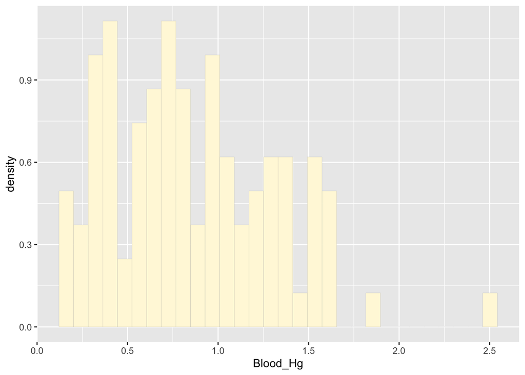

```r
p1 <- ggplot(data=z,aes(x=Blood_Hg,y=..density..))+ geom_histogram(color="grey60",fill="cornsilk",size=0.05)
print(p1)
```

Add empirical density curve

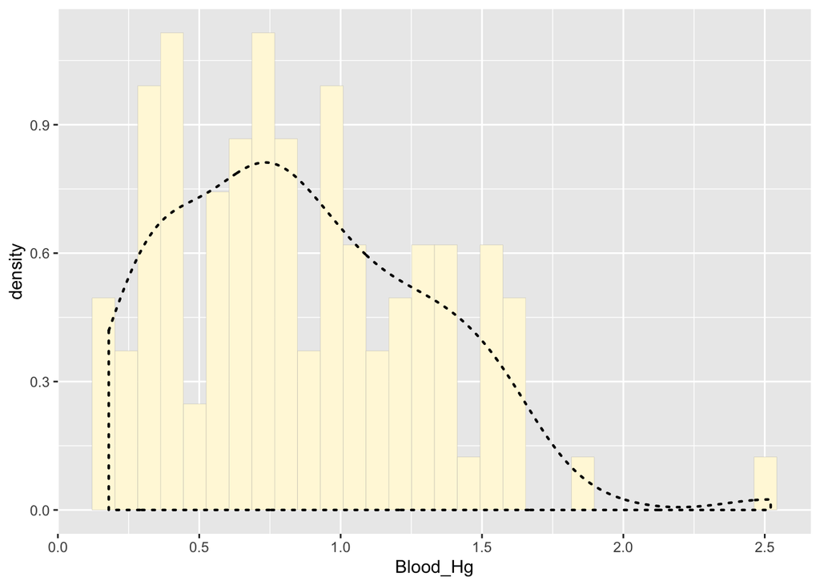

```r
p1 <-  p1 +  geom_density(linetype="dotted",size=0.75)
print(p1)
```

Get maximum likelihood parameters for normal

```r
normPars <- fitdistr(z$Blood_Hg,"normal")
print(normPars)
```

```
##       mean          sd
##   0.85764000   0.45156595
##  (0.04515660) (0.03193053)
```

```r
str(normPars)
```

```
## List of 5
##  $ estimate: Named num [1:2] 0.858 0.452
##   ..- attr(*, "names")= chr [1:2] "mean" "sd"
##  $ sd      : Named num [1:2] 0.0452 0.0319
##   ..- attr(*, "names")= chr [1:2] "mean" "sd"
##  $ vcov    : num [1:2, 1:2] 0.00204 0 0 0.00102
##   ..- attr(*, "dimnames")=List of 2
##   .. ..$ : chr [1:2] "mean" "sd"
##   .. ..$ : chr [1:2] "mean" "sd"
##  $ n       : int 100
##  $ loglik  : num -62.4
##  - attr(*, "class")= chr "fitdistr"
```

```r
normPars$estimate["mean"] # note structure of getting a named attribute
```

```
##    mean
## 0.85764
```

Plot normal probability density # first we get the maximum liklihood parameters by calling fitdistr # then we pass those parameters

```r
meanML <- normPars$estimate["mean"]
sdML <- normPars$estimate["sd"]

xval <- seq(0,max(z$Blood_Hg),len=length(z$Blood_Hg))

 stat <- stat_function(aes(x = xval, y = ..y..), fun = dnorm, colour="red", n = length(z$Blood_Hg), args = list(mean = meanML, sd = sdML))
 p1 + stat
```

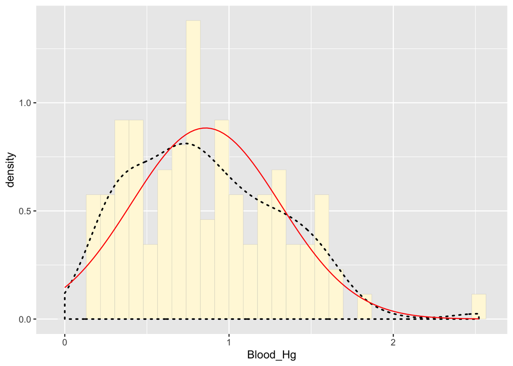

Plot exponential probability density

```r
expoPars <- fitdistr(z$Blood_Hg,"exponential")
rateML <- expoPars$estimate["rate"]

stat2 <- stat_function(aes(x = xval, y = ..y..), fun = dexp, colour="blue", n = length(z$Blood_Hg), args = list(rate=rateML))
 p1 + stat + stat2
```

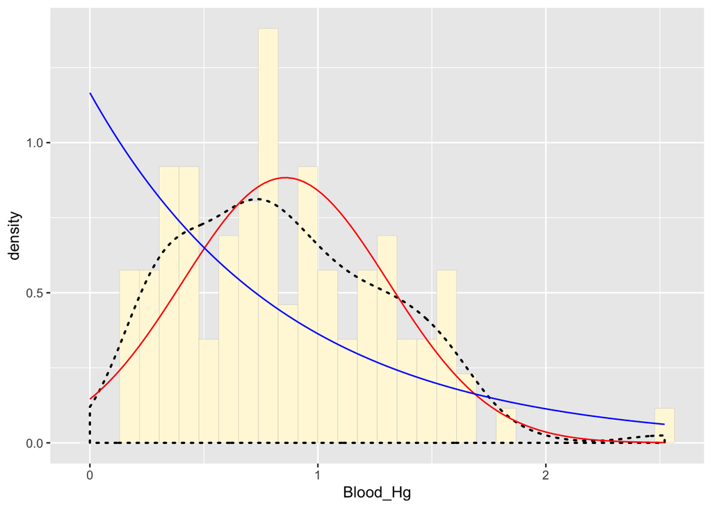

The blue curve is the exponential probabiltiy density

Plot uniform probability density

```r
stat3 <- stat_function(aes(x = xval, y = ..y..), fun = dunif, colour="darkgreen", n = length(z$Blood_Hg), args = list(min=min(z$Blood_Hg), max=max(z$Blood_Hg)))
 p1 + stat + stat2 + stat3
```

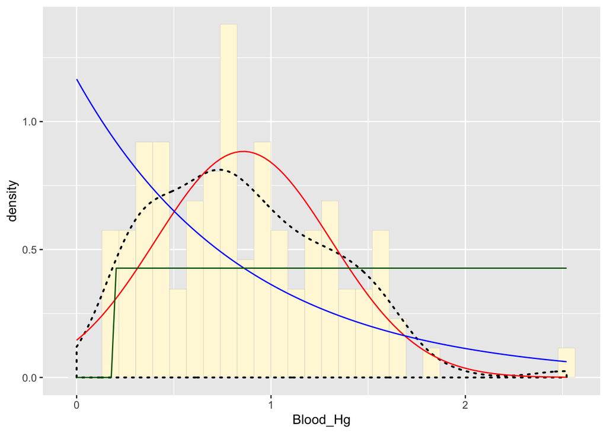

The green line is the uniform probability density

Plot Gamma probability density

```r
gammaPars <- fitdistr(z$Blood_Hg,"gamma")
shapeML <- gammaPars$estimate["shape"]
rateML <- gammaPars$estimate["rate"]

stat4 <- stat_function(aes(x = xval, y = ..y..), fun = dgamma, colour="brown", n = length(z$Blood_Hg), args = list(shape=shapeML, rate=rateML))
 p1 + stat + stat2 + stat3 + stat4
```

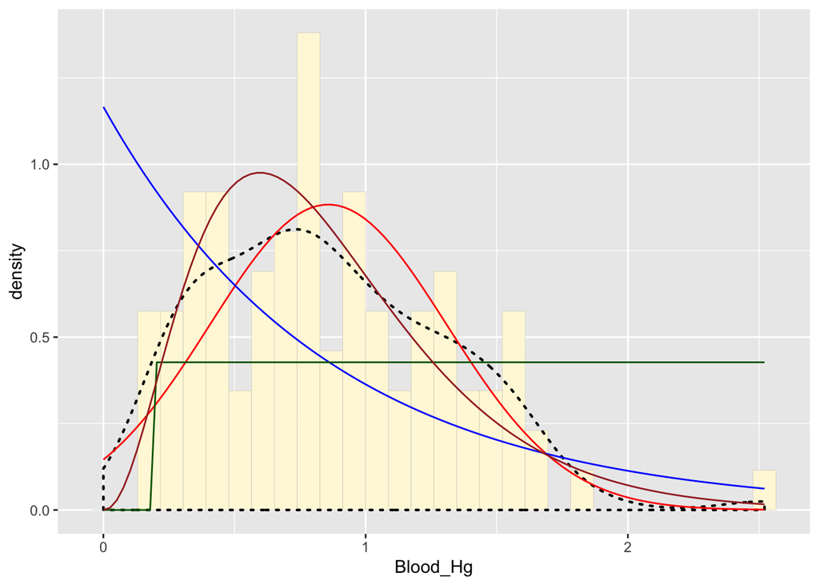

The darker red line is the gamma probability density. The gamma probability density seems to fit the data the best. It shows that majority of the individuals have lower blood Hg levels, and it seems to follow the empirical density curve the closest.

Plot beta probability density

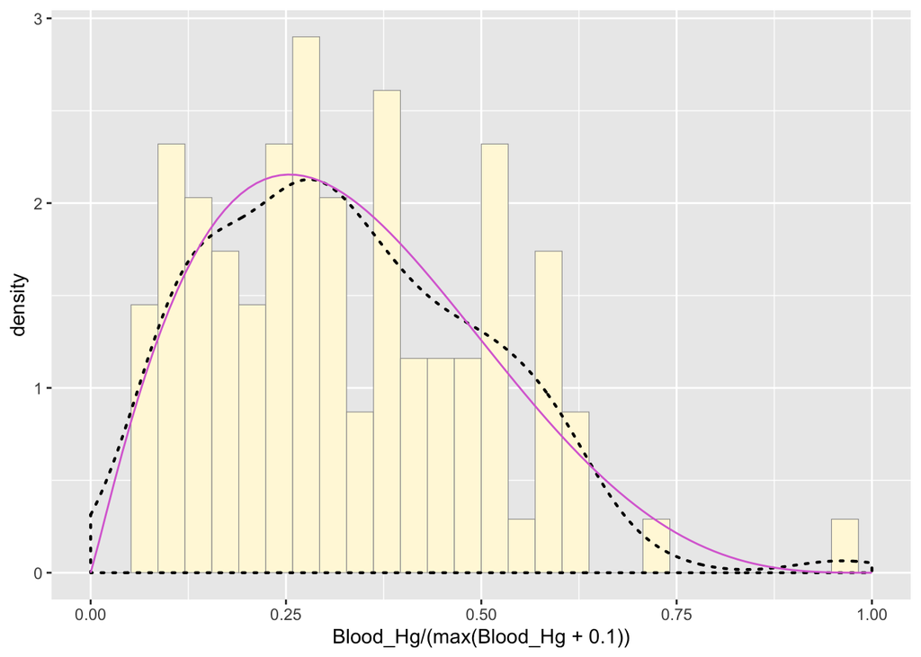

```r
pSpecial <- ggplot(data=z, aes(x=Blood_Hg/(max(Blood_Hg + 0.1)), y=..density..)) +
  geom_histogram(color="grey60",fill="cornsilk",size=0.2) +
  xlim(c(0,1)) +
  geom_density(size=0.75,linetype="dotted")

betaPars <- fitdistr(x=z$Blood_Hg/max(z$Blood_Hg + 0.1),start=list(shape1=1,shape2=2),"beta")
shape1ML <- betaPars$estimate["shape1"]
shape2ML <- betaPars$estimate["shape2"]

statSpecial <- stat_function(aes(x = xval, y = ..y..), fun = dbeta, colour="orchid", n = length(z$Blood_Hg), args = list(shape1=shape1ML,shape2=shape2ML))
pSpecial + statSpecial
```

Pink line is the beta probability density

5. Gamma distribution fits the data the best (out of normal, uniform, exponential, and gamma)…

Get new maximum likelihood parameters for gamma distribution:

```r
gammaPars <- fitdistr(z$Blood_Hg,"gamma")
print(gammaPars)
```

```
##      shape       rate
##   3.2936783   3.8403981
##  (0.4442298) (0.5595254)
```

```r
z2 <- rgamma(100,shape=3.2936783,rate=3.8403981)
print(z2)
```

```
##   [1] 1.7547779 1.0718236 0.2615191 0.2021149 1.5708054 0.4250975 0.6256678
##   [8] 0.2746664 0.6149995 0.3077703 0.2105369 1.9170670 0.8144451 0.8024276
##  [15] 1.3010630 1.3083816 0.5784669 0.9462194 0.5099470 0.2642251 0.5104058
##  [22] 1.0095563 0.6289694 0.4172394 0.6967181 0.6805908 0.4838547 0.7193161
##  [29] 0.9774713 1.0087707 0.5510564 1.5624881 1.0557822 0.8136749 0.2987797
##  [36] 0.2589149 0.6763445 0.3892579 0.6334356 0.6133022 0.1788645 1.3494367
##  [43] 0.6922823 0.8846952 0.5257579 0.6023203 1.1101844 0.7058129 0.4918086
##  [50] 1.1455229 0.6287778 1.0405331 1.4127555 0.3634356 0.9794984 0.6439961
##  [57] 0.8321009 0.8173866 0.8173319 0.3710773 0.4402452 1.6200448 1.2486771
##  [64] 0.7492436 0.8847778 0.3923545 0.5260004 2.8042527 0.2638566 0.5080445
##  [71] 0.8598917 0.6484455 0.8899766 0.2141361 1.4002756 1.0439461 1.0239110
##  [78] 0.6089156 0.7488700 0.2188510 1.0377482 0.0781910 1.4913056 1.0637082
##  [85] 0.3169653 1.0980827 0.9575795 0.1511783 0.4466156 1.5412437 0.3300974
##  [92] 2.0394071 0.5951077 1.1737992 0.6212601 1.1686157 1.3143684 0.5830674
##  [99] 2.3442317 0.7827357
```

Plot new data in a histogram and add the gamma probability density curve:

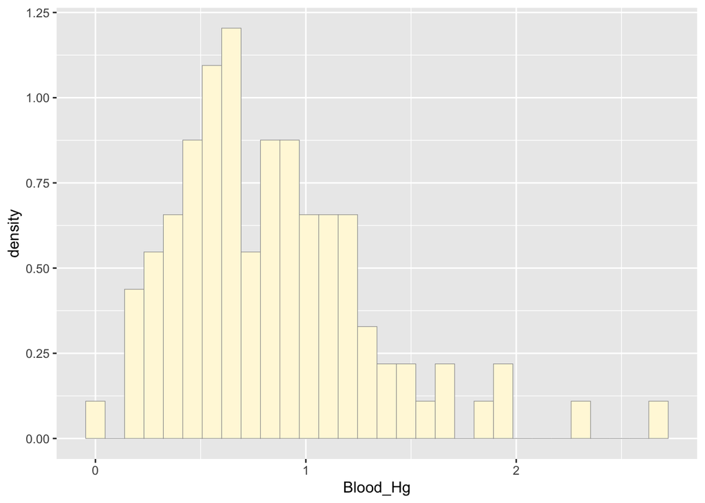

```r
new_gamma <- read.table("gamma_data.csv",header=TRUE,sep=",", stringsAsFactors=FALSE)

p2 <- ggplot(data=new_gamma, aes(x=Blood_Hg, y=..density..)) +
  geom_histogram(color="grey60",fill="cornsilk",size=0.2)
print(p2)
```

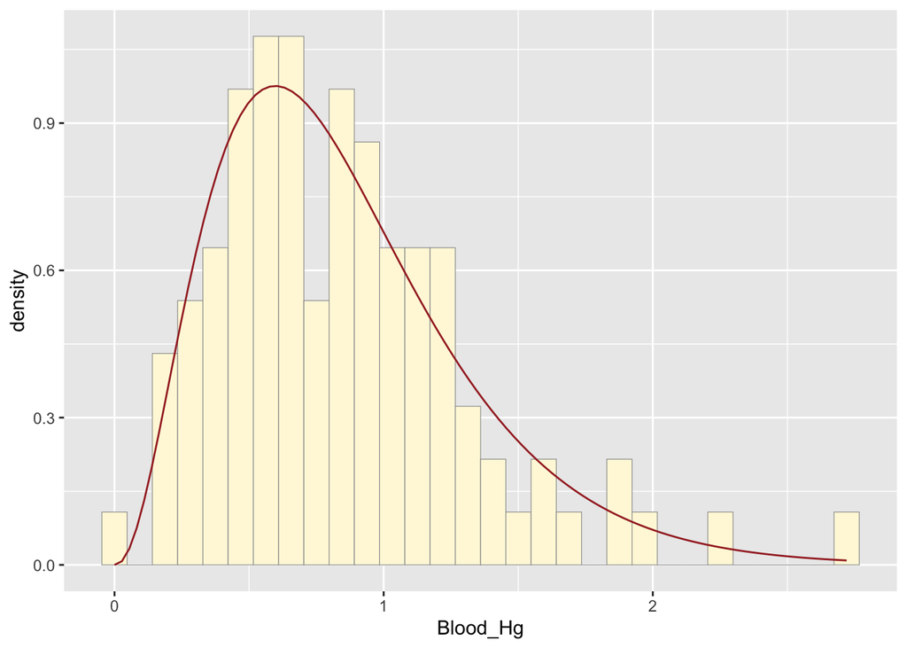

```r
gammaPars <- fitdistr(z$Blood_Hg,"gamma")
shapeML <- gammaPars$estimate["shape"]
rateML <- gammaPars$estimate["rate"]

xval <- seq(0,max(new_gamma$Blood_Hg),len=length(new_gamma$Blood_Hg))

newstat <- stat_function(aes(x = xval, y = ..y..), fun = dgamma, colour="brown", n = length(z$Blood_Hg), args = list(shape=shapeML, rate=rateML))
p2+newstat
```

The two histogram profiles are very similar,but the new model seems to follow the curve a little more closely. I think the model is doing a good job of simulating realistic data that match my original measurements because the highest density is still in the same place, and the curve is still positioned to the left. I only had 100 samples, so my data by itself does not show a strong distribution. With the curve however, it maps out how the blood mercury data might look if there were more samples.